# Progetto di Applicazioni Data Intensive 2018/2019

**Orazi Filippo 0000801069**

**Alesiani Matteo 0000806466**

## Descrizione del problema

Il problema da noi analizzato si pone l'obbiettivo di prevedere per conto di una società che effettua bike sharing (ossia una forma di affitto di biciclette automatizzato) il numero di biciclette che saranno affittate durante una giornata che presenta determinate caratteristiche.

Il dataset denominato "Bike Sharing Data Set" è stato scaricato dal sito https://archive.ics.uci.edu/ml e si compone di 731 istanze, 16 diversi attributi di cui 2 identificatori e 3 possibili soggetti di predizione.

```python
import os.path
import csv
import pandas as pd

if os.path.exists("day.csv"):
    ds = pd.read_csv("day.csv", sep=",")
else:
    print("File non trovato")
```

```python
len(ds.columns)
```

```
16
```

### Descrizione variabili

Il dataset scelto presenta variabili strutturate, ovvero i cui valori sono noti.

Vengono di seguito descritte:

- **instant**: indice dei record.
- **dteday**: data.
- **season**: stagione
- **yr**: anno (0: 2011, 1: 2012)
- **mnth**: mese (1 - 12)
- **holiday**: giorno festivo (1: si, 0: no)
- **weekday**: giorno della settimana (0 - 6)
- **workingaday**: se il giorno è festivo o appartiene al weekend 0, altrimenti 1
- **wheathersit**: condizioni meteo generali della giornata:
  - 1: soleggiato, poco nuvoloso
  - 2: nuvoloso, nebbia
  - 3: leggera neve, leggera pioggia
  - 4: neve, pioggia, fulmini
- **temp**: temperatura media giornaliera (C) normalizzata. Valori divisi per 41.
- **atemp**: temperatura perepita (°C) normaizzata. Valori divisi per 50
- **hum**: percentuale di umidità
- **windspeed**: velocità del vento normalizzata, Valori divisi per 67.
- **casual**: numero di utenti casuali
- **registered**: numero di utenti registrati
- **cnt**: numero di utenti totali

La variabile scelta come oggeto di predizione è la variabile "cnt" in quanto a fini di ricerca di mercato è la variabile che più interessa. Vengono qundi esclusi gli attributi "casual" e "registered", di cui "cnt" è la somma, e le relative colonne.

Osserviamo come la variabile da predire sia di tipo continuo. La metodologia utilizzata, per la risoluzione del problema, attua un algoritmo di regressione.

Concludianmo la descrizione delle variabili definendo come indice del dataframe l'attrbuto "dteday" e eliminando "instant", poichè svolge la stessa funzione.

```python
ds.set_index(["dteday"], inplace=True)
dataset = ds.drop(["casual", "registered","instant"], axis=1)
Y = dataset["cnt"]
```

## Analisi esplorativa

Il compito dell'analisi esplorativa consiste nel identificare nel dataset le caratteristiche degli attirbuti (feature) che possono influenzare la creazione del modello, ad esempio la presenza di valori nulli comporterebbe l'esigenza di attuare contromisure volte alla loro gestione.

Altro compito dell'analisi sta nel rappresentare l'insieme dei dati attraveso indici di correlazione tra variabili, grafici e descizioni matematiche.

Possiamo ottenere un inisieme di descrittori matematici dei vari attibuti attraverso la funzione *describe*.

```python
dataset.describe()
```

|  | season | yr | mnth | holiday | weekday | workingday | weathersit | temp | atemp | hum | windspeed | cnt |
| --- | --- | --- | --- | --- | --- | --- | --- | --- | --- | --- | --- | --- |
| count | 731.000000 | 731.000000 | 731.000000 | 731.000000 | 731.000000 | 731.000000 | 731.000000 | 731.000000 | 731.000000 | 731.000000 | 731.000000 | 731.000000 |
| mean | 2.496580 | 0.500684 | 6.519836 | 0.028728 | 2.997264 | 0.683995 | 1.395349 | 0.495385 | 0.474354 | 0.627894 | 0.190486 | 4504.348837 |
| std | 1.110807 | 0.500342 | 3.451913 | 0.167155 | 2.004787 | 0.465233 | 0.544894 | 0.183051 | 0.162961 | 0.142429 | 0.077498 | 1937.211452 |
| min | 1.000000 | 0.000000 | 1.000000 | 0.000000 | 0.000000 | 0.000000 | 1.000000 | 0.059130 | 0.079070 | 0.000000 | 0.022392 | 22.000000 |
| 25% | 2.000000 | 0.000000 | 4.000000 | 0.000000 | 1.000000 | 0.000000 | 1.000000 | 0.337083 | 0.337842 | 0.520000 | 0.134950 | 3152.000000 |
| 50% | 3.000000 | 1.000000 | 7.000000 | 0.000000 | 3.000000 | 1.000000 | 1.000000 | 0.498333 | 0.486733 | 0.626667 | 0.180975 | 4548.000000 |
| 75% | 3.000000 | 1.000000 | 10.000000 | 0.000000 | 5.000000 | 1.000000 | 2.000000 | 0.655417 | 0.608602 | 0.730209 | 0.233214 | 5956.000000 |
| max | 4.000000 | 1.000000 | 12.000000 | 1.000000 | 6.000000 | 1.000000 | 3.000000 | 0.861667 | 0.840896 | 0.972500 | 0.507463 | 8714.000000 |

La Funzione *info* di *pandas.Dataframe* permette di conoscere un ulteriore insieme di informazioni del dataframe

```python
dataset.info(memory_usage="deep")
```

```
<class 'pandas.core.frame.DataFrame'>
Index: 731 entries, 2011-01-01 to 2012-12-31
Data columns (total 12 columns):
season        731 non-null int64
yr            731 non-null int64
mnth          731 non-null int64
holiday       731 non-null int64
weekday       731 non-null int64
workingday    731 non-null int64
weathersit    731 non-null int64
temp          731 non-null float64
atemp         731 non-null float64
hum           731 non-null float64
windspeed     731 non-null float64
cnt           731 non-null int64
dtypes: float64(4), int64(8)
memory usage: 116.4 KB
```

Proseguiamo l'analisi del Dataset verificando la correlazione che l'attributo da predire ha in relazione agli altri. La correlazione di due variabili casuali X e Y, è dato dal rapporto tra la loro covarianza $\sigma$XY e il prodotto delle deviazioni standard $\sigma$X e $\sigma$ $\rho$(X,Y)= $\frac{\sigma XY}{\sigma X \sigma Y}$

Il coefficiente ha un valore compreso tra 1 e -1, dove valori vicini a 1 indicano correlazione diretta (Y cresce al crescere di X) valori vicini a -1 indicano correlazione inversa (Y descresce al crescere di X) valori vicini a 0 indicano assenza di correlazione

Le seguanti funzioni consentono di calcolare la correlazione tra due serie e il grafico relativo:

```python
import numpy as np
def getCorrelation(feature1, feature2):
    return np.mean((feature1-feature1.mean()) * (feature2-feature2.mean())) / (feature1.std() * feature2.std())
```

```python
import matplotlib.pyplot as plot
def plotData(x, y, XAxisName, YAxisName):
    plot.scatter(x, y)
    plot.grid()
    plot.xlabel(XAxisName); plot.ylabel(YAxisName)
    plot.show()
```

Mentre con la seguente si può ottenere una serie ordinata che indica la correlazione tra "cnt" e il nostro dataset indicizzato su "dtaday" e un grafico a dispersione di ogni feature con l'obbiettivo

```python
def correlationRank(dataset, feature):
    correlation = []
    for a in dataset.columns:
        correlation.append(getCorrelation(dataset[a].astype("float"), feature))
        plotData(dataset[a].astype("float"), feature, a, "Byke Rent")
    cor = pd.Series(correlation, dataset.columns)
    cor.sort_values(ascending=False, inplace=True)
    return cor
```

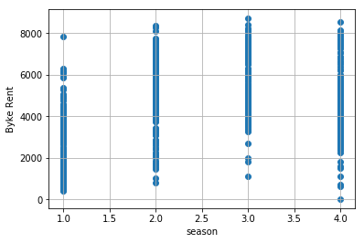

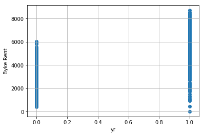

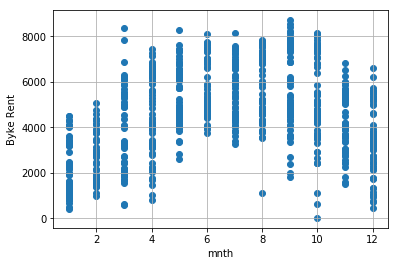

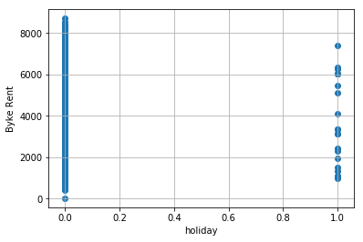

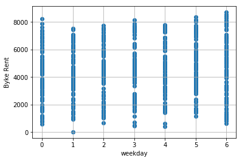

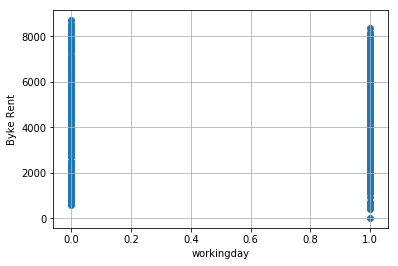

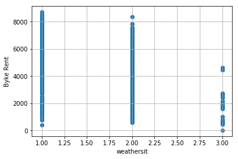

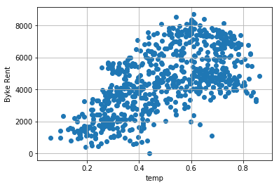

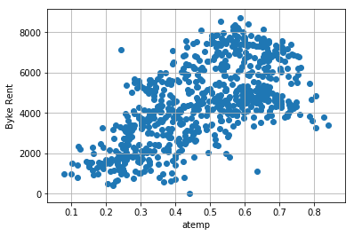

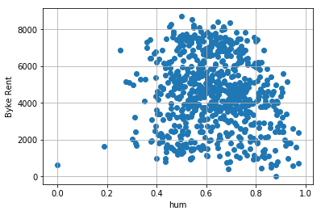

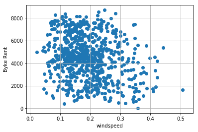

```python
cor = correlationRank(dataset.drop(["cnt"], axis=1),dataset["cnt"])
```

```python
print(cor)
```

```
atemp         0.630202
temp          0.626636
yr            0.565934
season        0.405545
mnth          0.279594
weekday       0.067351
workingday    0.061072
holiday      -0.068254
hum          -0.100521
windspeed    -0.234224
weathersit   -0.296984
dtype: float64
```

Dai grafici e dal calcolo della correlazione scopriamo che gli attributi weekday workingday e holiday sono attributi poco importanti per il calcolo. Nonostante ciò essendo la correlazione un calcolo su un coefficente di primo grado questi attributi poco correlati non vengono esclusi dal calcolo in quanto questo si baserà verosimilmente su un algoritmo polinomiale.

## Preaparazione dei dati

Molti dei dati sono già stati standardizzati alla creazione del dataset, i dati che normalmente vengono presentati come categorici sono già forniti in forma numerica

I dati che necessitano di standardidazione verranno elaborati successivamente in ogni Pipeline attraverso la funzione di sklearn *StandardScaler*

Essendo questo un problema di regressione calcoliamo con la norma L1, le feature più rilevanti, ma prima dividiamo il dataset in trainSet e ValidationSet.

- Training set: come si evince dal nome stesso, verrà utilizzato per allenare l'algoritmo di learning
- Validation set: modello utilizzato per verificare l'accuratezza del modello generato.

Spesso è utilizzato un terzo insieme dei dati, definito Test set. Qual'ora i risulati del validation set siano soddisfacenti, è consigliabile testare il modello su valori diversi e non "visti" in precedenza. Ciò permetterà di misurare l'accuratezza a pieno regime.

```python
from sklearn.model_selection import train_test_split
Y = dataset["cnt"]
X = dataset.drop(["cnt"], axis=1)
XTrain, XVal, YTrain, YVal = train_test_split(X, Y, test_size=0.33, random_state=73)
```

Il modello Lasso è un modello di regressione lineare che aggiunge la norma L1$ | \theta |_1 = \sum_{i=1}^n |\theta_i |$ alla funzione d'errore della discesa del gradiente, in modo da regolarizzare ed eventualmente azzerare i coefficienti $\theta$ del modello.

Questa operazione permette di ridurre le oscillazione ed aumentare l'accuratezza del modello riconscendo ed escludendo dal calcolo variabili che non sono influenti.

```python
from sklearn.pipeline import Pipeline
from sklearn.preprocessing import StandardScaler, PolynomialFeatures
from sklearn.linear_model import Lasso

def elaborationWithLasso(degeePipe=1, alphaPipe=0):
    return Pipeline([("poly", PolynomialFeatures(degree=degeePipe, include_bias=False)),
                    ("scale",  StandardScaler()),
                    ("linreg", Lasso(alpha=alphaPipe, max_iter=6000, tol=0.005))])
```

```python
def showZerosFeatures(XTrain, YTrain):
    model = elaborationWithLasso(1,2)
    model.fit(XTrain, YTrain)
    tmp = pd.Series(model.named_steps["linreg"].coef_, XTrain.columns)
    print(tmp)
    a = []
    for row in tmp.index:
        if(tmp[row]==0):
            a.append(row)
    print(a)
```

```python
showZerosFeatures(XTrain, YTrain)
```

```
season         543.090176
yr            1029.734537
mnth          -119.037291
holiday        -79.024799
weekday        136.482490
workingday      42.310286
weathersit    -355.379160
temp           511.234902
atemp          368.312876
hum            -92.656684
windspeed     -175.260109
dtype: float64
[]
```

Nessun coefficiente viene impostato a 0 per cui non andremo ad escludere manualmente nessun attributo.

Di seguito valutiamo la qualità del modello attraverso il calcolo degli indici di errore quadratico medio, errore relativo e $R^2$

```python
def relativeError(YTrue, YPred):
    return np.mean(np.abs((YTrue - YPred) / YTrue))
```

```python
from sklearn.metrics import mean_squared_error
def printEvalutation(X, Y, model):
    print("Mean squared error    : {:.5}".format(mean_squared_error(model.predict(X), Y)))
    print("Relative error        : {:.5%}".format(relativeError(model.predict(X), Y)))
    print("R-squared coefficient : {:.5}".format(model.score(X, Y)))
```

```python
model = elaborationWithLasso(1, 2)
model.fit(XTrain, YTrain)
printEvalutation(XVal, YVal, model)
```

```
Mean squared error    : 6.805e+05
Relative error        : 18.43333%
R-squared coefficient : 0.8367
```

Il risultato è buono ma sono possibili miglioramenti per cui tenteremeo di usare nuovamene questo tipo di modello successivamente.

## Generazione modelli di learning

Generiamo adesso diversi modelli di learning utilizzando k (nested) cross fold validation applicata ad una grid search.

Il metodo di learning di riferimento, come già detto, sarà la regressione, la quale permette di stimare una data variabile $Y$ in base alla relazione con le altre variabili $X = \{x_1,...,x_n\}$ con $n > 0$. Il tutto avviene attraverso la discesa del gradiente che, variando i coefficienti $\theta$ delle variabili $X$, permete la diminuzione progressiva dell'errore calcolato tra la funzione di stima e il caso reale.

Per ogni classe di modello costruiamo ora le Pipeline che ci permetteranno di addestrarlo

Il modello Ridge è un modello di regressione lineare che aggiunge la norma L2$ \Vert \theta \Vert_2^2 = \sum_{i=1}^n \theta _i ^2$ alla funzione d'errore della discesa del gradiente, in modo da regolarizzare le dimensioni dei coefficienti del modello che per gradi del polinomio molto alti potrebbero assumere valori elvati. Questo permette di ridurre le oscillazione ed aumentare l'accuratezza del modello.

```python
from sklearn.linear_model import Ridge

def elaborationWithRidge():
    return Pipeline([("poly", PolynomialFeatures(include_bias=False)),
                    ("scale",  StandardScaler()),
                    ("linreg", Ridge())])
```

Il modello Elastic Net è un modello di regressione lineare che applica si la norma L1 sia la norma L2 in questo modo $ \alpha \Vert \theta \Vert_1 + (1 - \alpha) \Vert \theta \Vert_2$. l'iperparametro $\alpha$ indica quanto il modello è "sbilanciato verso la norma L1

```python
from sklearn.linear_model import ElasticNet

def elaborationWithElasticNet():
    return Pipeline([("poly",   PolynomialFeatures(include_bias=False)),
                     ("scale",  StandardScaler()),
                     ("linreg",  ElasticNet(tol = 0.05, max_iter = 6000))])
```

Creiamo anche un modello di regressione lineare senza restrizioni

```python
from sklearn.linear_model import LinearRegression

def elaborationWithoutRestrain():
    return Pipeline([("poly",  PolynomialFeatures(include_bias=False)),
                    ("scale",  StandardScaler()),
                    ("linreg", LinearRegression())])
```

Ora definiamo il grado e gli iperparametri migliori attraverso una gridsearch con cross validation e addestriamo i modelli.

Il cross validation risulta estremamente utile per l'addestramento perche divide il datset che viene passato in k gruppi, ciascun gruppo è poi validato su un modello addestrato su tutti gli altri gruppi. Questo approccio migliora la valutazione dei modelli in confronto al metodo di Hold-out.

```python
from sklearn.model_selection import GridSearchCV

parRidge = {
    "poly__degree": [1,6,8],
    "linreg__alpha":  [1,2,6]
}
model = elaborationWithRidge()
ridgeGridSearch = GridSearchCV(model, param_grid=parRidge)
ridgeGridSearch.fit(X, Y)
print(ridgeGridSearch.best_params_)
```

[output not shown]

```python
parLasso = {
    "poly__degree": [1,6,8],
    "linreg__alpha":  [1,5,8]
}
LassoModel = elaborationWithLasso()
lassoGridSearch = GridSearchCV(LassoModel, param_grid=parLasso)
lassoGridSearch.fit(XTrain, YTrain)
print(lassoGridSearch.best_params_)
```

[output not shown]

```python
parNet = {
    "poly__degree": [1,2,6],
    "linreg__alpha": [1,2,8],
    "linreg__l1_ratio": [0.1, 0.5, 1.0]
}
NETmodel = elaborationWithElasticNet()
ENgridSearch = GridSearchCV(NETmodel, param_grid=parNet)
ENgridSearch.fit(XTrain, YTrain)
print(ENgridSearch.best_params_)
```

[output not shown]

```python
from sklearn.model_selection import GridSearchCV

parNR = {
   "poly__degree": [1,2],
}
NRmodel = elaborationWithoutRestrain()
NRGridSearch = GridSearchCV(NRmodel, param_grid=parNR)
NRGridSearch.fit(XTrain, YTrain)
print(NRGridSearch.best_params_)
```

[output not shown]

## Valutazione modelli

Valutiamo ora i modelli ricavati nel punto precedente attraverso le metriche gia introdotte di $R^2$, errore relativo e errore quadratico medio. aggiungiamo alla valutazione una tabella ottenuta attraverso l'attributo *cv_results* di *GridSearchCV* in modo da verificare quali parametri hanno portato un risultato migliore nei vari tipi di regressione.

```python
def EvalutationTable(results):
    return pd.DataFrame(results.cv_results_).sort_values("mean_test_score", ascending=False)
```

```python
printEvalutation(XVal, YVal, lassoGridSearch)
EvalutationTable(lassoGridSearch)
```

```
Mean squared error    : 4.375e+05
Relative error        : 14.49989%
R-squared coefficient : 0.89501
```

|  | mean_fit_time | std_fit_time | mean_score_time | std_score_time | param_linreg__alpha | param_poly__degree | params | split0_test_score | split1_test_score | split2_test_score | mean_test_score | std_test_score | rank_test_score |
| --- | --- | --- | --- | --- | --- | --- | --- | --- | --- | --- | --- | --- | --- |
| 7 | 2.026778 | 0.385686 | 0.242197 | 0.001691 | 8 | 6 | {'linreg__alpha': 8, 'poly__degree': 6} | 0.853653 | 0.912994 | 0.830353 | 0.865667 | 0.034791 | 1 |
| 4 | 3.376660 | 0.478572 | 0.252330 | 0.008810 | 5 | 6 | {'linreg__alpha': 5, 'poly__degree': 6} | 0.850507 | 0.907317 | 0.829527 | 0.862450 | 0.032862 | 2 |
| 8 | 8.837437 | 0.723542 | 1.665664 | 0.110541 | 8 | 8 | {'linreg__alpha': 8, 'poly__degree': 8} | 0.853018 | 0.873217 | 0.831365 | 0.852533 | 0.017089 | 3 |
| 5 | 13.761474 | 0.822179 | 1.509044 | 0.018292 | 5 | 8 | {'linreg__alpha': 5, 'poly__degree': 8} | 0.845666 | 0.834053 | 0.822341 | 0.834020 | 0.009523 | 4 |
| 1 | 11.725694 | 3.374477 | 0.246336 | 0.006360 | 1 | 6 | {'linreg__alpha': 1, 'poly__degree': 6} | 0.789166 | 0.751333 | 0.759454 | 0.766651 | 0.016262 | 5 |
| 6 | 0.006316 | 0.002048 | 0.002991 | 0.001409 | 8 | 1 | {'linreg__alpha': 8, 'poly__degree': 1} | 0.759610 | 0.800192 | 0.693349 | 0.751050 | 0.044036 | 6 |
| 0 | 0.015626 | 0.002047 | 0.005316 | 0.001693 | 1 | 1 | {'linreg__alpha': 1, 'poly__degree': 1} | 0.756518 | 0.802837 | 0.692739 | 0.750698 | 0.045135 | 7 |
| 3 | 0.006983 | 0.002156 | 0.003330 | 0.001889 | 5 | 1 | {'linreg__alpha': 5, 'poly__degree': 1} | 0.758797 | 0.800728 | 0.692468 | 0.750664 | 0.044570 | 8 |
| 2 | 39.967745 | 10.855220 | 1.534200 | 0.011069 | 1 | 8 | {'linreg__alpha': 1, 'poly__degree': 8} | 0.765142 | 0.619144 | 0.744135 | 0.709474 | 0.064446 | 9 |

```python
printEvalutation(XVal, YVal, ridgeGridSearch)
EvalutationTable(ridgeGridSearch)
```

[output not shown]

```python
printEvalutation(XVal, YVal, NRGridSearch)
EvalutationTable(NRGridSearch)
```

[output not shown]

```python
printEvalutation(XVal, YVal, ENgridSearch)
EvalutationTable(ENgridSearch)
```

```
Mean squared error    : 5.6638e+05
Relative error        : 15.86626%
R-squared coefficient : 0.86408
```

|  | mean_fit_time | std_fit_time | mean_score_time | std_score_time | param_linreg__alpha | param_linreg__l1_ratio | param_poly__degree | params | split0_test_score | split1_test_score | split2_test_score | mean_test_score | std_test_score | rank_test_score |
| --- | --- | --- | --- | --- | --- | --- | --- | --- | --- | --- | --- | --- | --- | --- |
| 14 | 7.257461 | 5.981885 | 0.242590 | 0.003715 | 2 | 0.5 | 6 | {'linreg__alpha': 2, 'linreg__l1_ratio': 0.5, ... | 0.831632 | 0.901721 | 0.803112 | 0.845488 | 0.041432 | 1 |
| 26 | 0.641817 | 0.021716 | 0.239435 | 0.004211 | 8 | 1 | 6 | {'linreg__alpha': 8, 'linreg__l1_ratio': 1.0, ... | 0.835492 | 0.913035 | 0.783830 | 0.844119 | 0.053099 | 2 |
| 5 | 2.204465 | 1.649292 | 0.246253 | 0.001899 | 1 | 0.5 | 6 | {'linreg__alpha': 1, 'linreg__l1_ratio': 0.5, ... | 0.824544 | 0.908612 | 0.776951 | 0.836703 | 0.054434 | 3 |
| 2 | 23.274296 | 27.598039 | 0.273652 | 0.025203 | 1 | 0.1 | 6 | {'linreg__alpha': 1, 'linreg__l1_ratio': 0.1, ... | 0.822241 | 0.901453 | 0.769070 | 0.830921 | 0.054392 | 4 |
| 17 | 0.633198 | 0.011879 | 0.266045 | 0.035211 | 2 | 1 | 6 | {'linreg__alpha': 2, 'linreg__l1_ratio': 1.0, ... | 0.815963 | 0.899629 | 0.755812 | 0.823801 | 0.058974 | 5 |
| 8 | 0.649112 | 0.003907 | 0.260462 | 0.022614 | 1 | 1 | 6 | {'linreg__alpha': 1, 'linreg__l1_ratio': 1.0, ... | 0.821826 | 0.892369 | 0.753376 | 0.822523 | 0.056746 | 6 |
| 11 | 58.757980 | 2.736113 | 0.259638 | 0.003084 | 2 | 0.1 | 6 | {'linreg__alpha': 2, 'linreg__l1_ratio': 0.1, ... | 0.783801 | 0.889907 | 0.781267 | 0.818325 | 0.050627 | 7 |
| 23 | 7.373223 | 2.025139 | 0.240346 | 0.003738 | 8 | 0.5 | 6 | {'linreg__alpha': 8, 'linreg__l1_ratio': 0.5, ... | 0.789340 | 0.863721 | 0.740863 | 0.797975 | 0.050527 | 8 |
| 25 | 0.008989 | 0.001641 | 0.003302 | 0.000438 | 8 | 1 | 2 | {'linreg__alpha': 8, 'linreg__l1_ratio': 1.0, ... | 0.791523 | 0.846855 | 0.705940 | 0.781439 | 0.057969 | 9 |
| 20 | 42.217569 | 3.074969 | 0.239356 | 0.001411 | 8 | 0.1 | 6 | {'linreg__alpha': 8, 'linreg__l1_ratio': 0.1, ... | 0.764985 | 0.837847 | 0.709756 | 0.770863 | 0.052458 | 10 |
| 24 | 0.005983 | 0.002820 | 0.002662 | 0.001695 | 8 | 1 | 1 | {'linreg__alpha': 8, 'linreg__l1_ratio': 1.0, ... | 0.759374 | 0.799857 | 0.694766 | 0.751332 | 0.043278 | 11 |
| 15 | 0.004998 | 0.000805 | 0.003647 | 0.001878 | 2 | 1 | 1 | {'linreg__alpha': 2, 'linreg__l1_ratio': 1.0, ... | 0.757909 | 0.801139 | 0.692804 | 0.750617 | 0.044527 | 12 |
| 6 | 0.005673 | 0.001243 | 0.002325 | 0.001237 | 1 | 1 | 1 | {'linreg__alpha': 1, 'linreg__l1_ratio': 1.0, ... | 0.757316 | 0.802127 | 0.691817 | 0.750420 | 0.045297 | 13 |
| 4 | 0.010097 | 0.000982 | 0.006193 | 0.000843 | 1 | 0.5 | 2 | {'linreg__alpha': 1, 'linreg__l1_ratio': 0.5, ... | 0.762480 | 0.799522 | 0.687821 | 0.749941 | 0.046456 | 14 |
| 1 | 0.011637 | 0.002349 | 0.005987 | 0.000815 | 1 | 0.1 | 2 | {'linreg__alpha': 1, 'linreg__l1_ratio': 0.1, ... | 0.755575 | 0.784114 | 0.681905 | 0.740531 | 0.043061 | 15 |
| 13 | 0.007303 | 0.000483 | 0.005999 | 0.000822 | 2 | 0.5 | 2 | {'linreg__alpha': 2, 'linreg__l1_ratio': 0.5, ... | 0.754112 | 0.780266 | 0.680744 | 0.738374 | 0.042126 | 16 |
| 16 | 0.014261 | 0.005285 | 0.005672 | 0.002054 | 2 | 1 | 2 | {'linreg__alpha': 2, 'linreg__l1_ratio': 1.0, ... | 0.771459 | 0.864472 | 0.571240 | 0.735724 | 0.122349 | 17 |
| 10 | 0.014968 | 0.009906 | 0.005977 | 0.001627 | 2 | 0.1 | 2 | {'linreg__alpha': 2, 'linreg__l1_ratio': 0.1, ... | 0.742031 | 0.755659 | 0.672322 | 0.723338 | 0.036500 | 18 |
| 7 | 0.018190 | 0.006374 | 0.006331 | 0.001245 | 1 | 1 | 2 | {'linreg__alpha': 1, 'linreg__l1_ratio': 1.0, ... | 0.758047 | 0.866946 | 0.529924 | 0.718306 | 0.140429 | 19 |
| 3 | 0.005301 | 0.000444 | 0.003663 | 0.001250 | 1 | 0.5 | 1 | {'linreg__alpha': 1, 'linreg__l1_ratio': 0.5, ... | 0.734897 | 0.719898 | 0.658703 | 0.704499 | 0.032956 | 20 |
| 22 | 0.007641 | 0.001692 | 0.002990 | 0.001409 | 8 | 0.5 | 2 | {'linreg__alpha': 8, 'linreg__l1_ratio': 0.5, ... | 0.699377 | 0.690472 | 0.641400 | 0.677083 | 0.025492 | 21 |
| 0 | 0.015469 | 0.002132 | 0.004655 | 0.002487 | 1 | 0.1 | 1 | {'linreg__alpha': 1, 'linreg__l1_ratio': 0.1, ... | 0.682686 | 0.651893 | 0.615933 | 0.650171 | 0.027279 | 22 |
| 12 | 0.006650 | 0.002050 | 0.002659 | 0.000940 | 2 | 0.5 | 1 | {'linreg__alpha': 2, 'linreg__l1_ratio': 0.5, ... | 0.669059 | 0.635776 | 0.604826 | 0.636554 | 0.026229 | 23 |
| 19 | 0.009320 | 0.001673 | 0.002833 | 0.000253 | 8 | 0.1 | 2 | {'linreg__alpha': 8, 'linreg__l1_ratio': 0.1, ... | 0.634090 | 0.610714 | 0.588004 | 0.610936 | 0.018815 | 24 |
| 9 | 0.007979 | 0.002821 | 0.001990 | 0.000007 | 2 | 0.1 | 1 | {'linreg__alpha': 2, 'linreg__l1_ratio': 0.1, ... | 0.573319 | 0.531653 | 0.524333 | 0.543102 | 0.021575 | 25 |
| 21 | 0.006822 | 0.002250 | 0.002327 | 0.001243 | 8 | 0.5 | 1 | {'linreg__alpha': 8, 'linreg__l1_ratio': 0.5, ... | 0.401212 | 0.361374 | 0.374033 | 0.378873 | 0.016620 | 26 |
| 18 | 0.006002 | 0.002830 | 0.002646 | 0.001701 | 8 | 0.1 | 1 | {'linreg__alpha': 8, 'linreg__l1_ratio': 0.1, ... | 0.278843 | 0.247209 | 0.263030 | 0.263028 | 0.012915 | 27 |

definiamo come modelli migliori i seguenti:

- regressione con lasso di grado 6 e con $\lambda$ = 8
- regressione con lasso di grado 6 e con $\lambda$ = 5
- regressione con Elastic net di grado 6 con $\lambda = 2$ e $\alpha = 0.5$

che presentano rispettivamente le seguenti metriche di giudizio

```python
LassoModel1 = Pipeline([("poly", PolynomialFeatures(degree=6, include_bias=False)),
                        ("scale",  StandardScaler()),
                        ("linreg", Lasso(alpha=8, max_iter=6000, tol=0.005))])
print("LassoModel1")
LassoModel1.fit(XTrain, YTrain)
count = 0
for a in LassoModel1.named_steps["linreg"].coef_ :
    if a != 0:
        count += 1
print("number of non zero param: " + str(count))
printEvalutation(XVal, YVal, LassoModel1)

print("\nLassoModel2")
LassoModel2 = Pipeline([("poly", PolynomialFeatures(degree=6, include_bias=False)),
                        ("scale",  StandardScaler()),
                        ("linreg", Lasso(alpha=5, max_iter=6000, tol=0.005))])
LassoModel2.fit(XTrain, YTrain)
count = 0
for a in LassoModel2.named_steps["linreg"].coef_ :
    if a != 0:
        count += 1
print("number of non zero param: " + str(count))

printEvalutation(XVal, YVal, LassoModel2)

print("\nENModel")
ENModel = Pipeline([("poly",   PolynomialFeatures(degree = 6, include_bias=False)),
                     ("scale",  StandardScaler()),
                     ("linreg",  ElasticNet(alpha=2, l1_ratio=0.5, tol = 0.05, max_iter = 6000))])
ENModel.fit(XTrain, YTrain)
count = 0
for a in ENModel.named_steps["linreg"].coef_ :
    if a != 0:
        count += 1
print("number of non zero param: " +  str(count))

printEvalutation(XVal, YVal, ENModel)
```

```
LassoModel1
number of non zero param: 167
Mean squared error    : 4.375e+05
Relative error        : 14.49989%
R-squared coefficient : 0.89501

LassoModel2
number of non zero param: 215
Mean squared error    : 4.7139e+05
Relative error        : 15.29182%
R-squared coefficient : 0.88688

ENModel
number of non zero param: 7877
Mean squared error    : 5.6638e+05
Relative error        : 15.86626%
R-squared coefficient : 0.86408
```

Dei tre modelli complessivamente molto buoni, viene scartato il modello con ElasticNet perchè nel complesso presenta risultati peggiori.

Dei due modelli che utilizzano il Lasso viene designato come migliore quello che presenta grado 6 e con $\lambda$ = 8 perchè ottiene prestazioni migliori in tutte le metriche di giudizio.  
Inoltre compie la propria elaborazione con un numero di coefficienti minore, ne consegue una elaborazione più efficente rispetto al carico computazionale.

Infine è importante considerare che la diminuzione del numero di coefficienti può portare al fenomeno dell'overfitting, ossia la costruzione di un modello troppo aderente al training set con un apparente aumento della qualità della previsione. Un Modello così sviluppato potrebbe non risultare descrittivo quando applicato ad un dataset ignoto.